# hw#6.data624

Sang Yoon (Andy) Hwang

October 7th, 2019

# 8.11 Exercises

# 8.1 Figure 8.31 shows the ACFs for 36 random numbers, 360 random numbers and 1,000 random numbers

# a. Explain the differences among these figures. Do they all indicate that the data are white noise?

Note: Conditions for being white noise (at least 1 condition should be met)

1. one or more large spikes are not outside these bounds (CI - 95%)
2. substantially less than 5% of spikes are outside these bounds

The X1 might not be white noise (lags are autocorrelated) given that large spike at 12 seems to go over the 95% CI. However, this is border line issue so we may have to rely on Box-LJung test to figure out whether p-value is less than 0.05 or not.

The x2 also might not be white noise given that relatively large spikes at lag 2 and lag 6 go over the CI but again, Box-LJung test is required to confirm this.

The x3 looks to be white noise since all lags are within CI and no one or more large spikes are outside CIs. However, we can see that spike at large 20 is on the borderline so we are not 100% sure. Box-LJung test is required once again.

However, it is 100% certain that all of these data do not have more than 5% of spikes going over the CIs which means the 2nd condition for being white noise is satisfied; but 1st condition which is about one or more large spike going over the CIs might not be identified visually so Box-LJung test is required to test validity of white noise to make sure if 1st condition is satisfied.

# b. Why are the critical values at different distances from the mean of zero? Why are the autocorrelations different in each figure when they each refer to white noise?

The critical values at different distances are from the mean of zero since we expect each autocorrelation to be close to zero for white noise series. If lag deviates from mean of zero and go over the CIs, it might indicate the data is autocorrelated (not white noise).

The autocorrelations are different in each figure since the size of the data for each figure is different. (in fact, the formula for CI is +-2/sqrt(N) given N = sample size) The bigger the N, sample size, the narrower the bounds. It looks like the fluctuation of spikes for each lag tends to become smaller as the size of the data increases.

# 8.2. A classic example of a non-stationary series is the daily closing IBM stock price series (data set `ibmclose`). Use R to plot the daily closing prices for IBM stock and the ACF and PACF. Explain how each plot shows that the series is non-stationary and should be differenced.

ggAcf shows that 2 conditions for being white noise are not satisfied. ggPacf shows that 1st condition is not satisfied, which is enough to say that data is not white noise (not stationary).

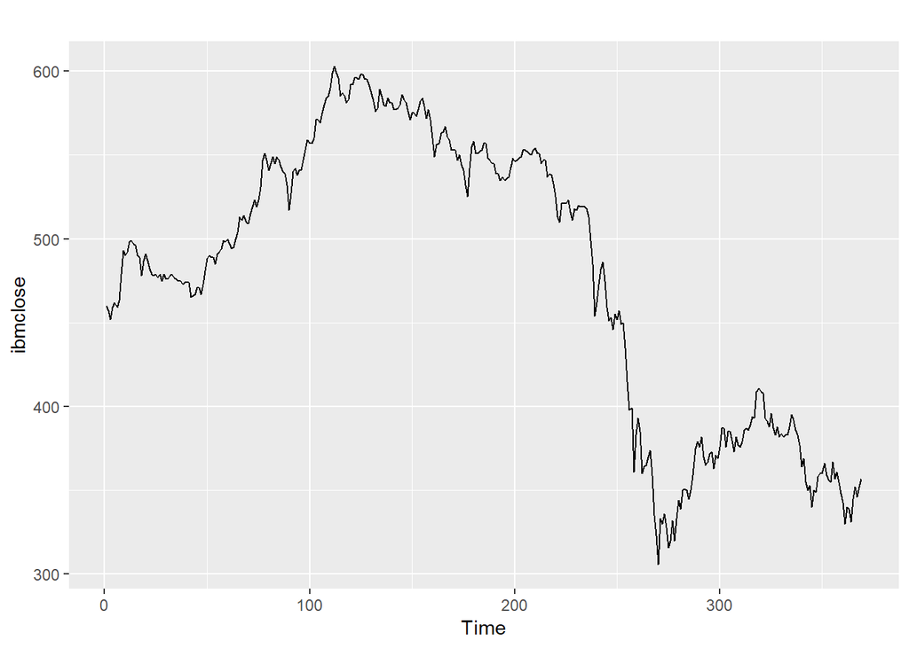

```r
autoplot(ibmclose) # + autolayer(ibmclose)
```

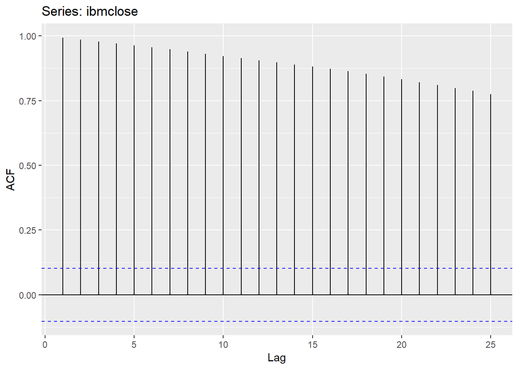

```r
ggAcf(ibmclose)
```

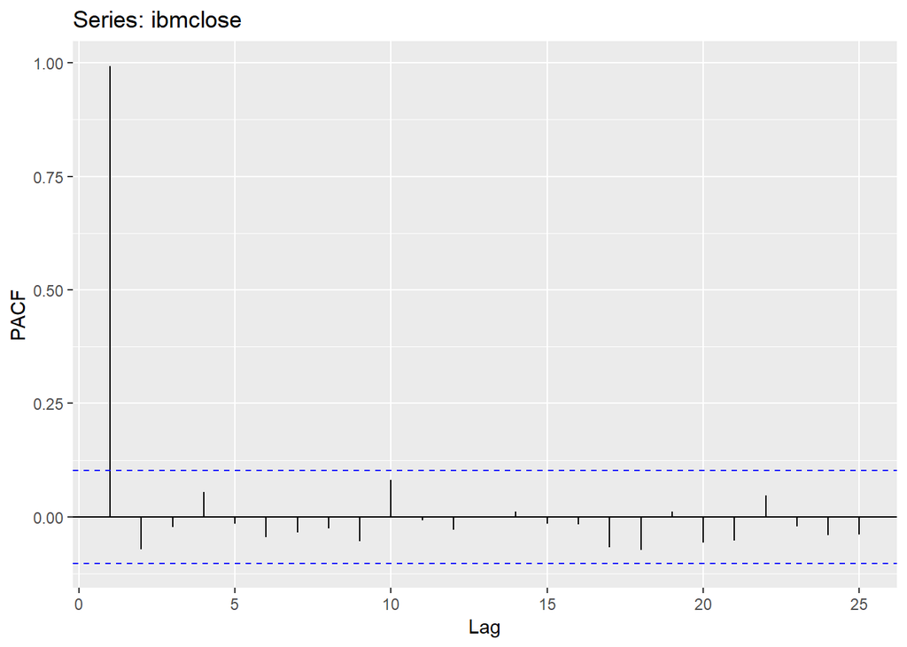

```r
ggPacf(ibmclose)
```

```r
Box.test(ibmclose, type = c("Ljung-Box"))
```

```
##
##  Box-Ljung test
##
## data:  ibmclose
## X-squared = 367.11, df = 1, p-value < 2.2e-16
```

# 8.6. Use R to simulate and plot some data from simple ARIMA models.

# a. Use the following R code to generate data from an AR(1) model with o1 = 0.6 and var = 1. The process starts with y1 = 0.

Data sets are generated from following codes.

```r
y <- ts(numeric(100))
e <- rnorm(100)
for(i in 2:100)
  y[i] <- 0.6*y[i-1] + e[i]

y
```

```
## Time Series:
## Start = 1
## End = 100
## Frequency = 1
##   [1]  0.000000000  2.505406706  0.651018416 -0.351132094 -0.732599075
##   [6]  1.120267155  1.464673784  0.652006648  0.351719689  1.196435539
##  [11]  0.874651728  0.250881677 -1.143143285  0.865157726 -0.581041270
##  [16] -0.059360350  0.110575768  1.249093889 -0.271020578  1.815929397
##  [21]  2.414473308 -0.328233340  0.469274823 -0.737727181 -0.722837472
##  [26] -0.161586990 -0.196415645 -0.673938576 -1.650814988 -1.492737314
##  [31] -0.003974671 -1.320755336 -1.942847778 -2.750137452 -3.346899282
##  [36] -2.029008032 -0.614547192 -1.541860322  1.965044014  1.044793500
##  [41]  2.256731296  0.583199233 -0.278158616  0.097434100  0.376265677
##  [46]  0.209852966 -0.146742340 -0.811413256  0.208324621  0.499372674
##  [51] -0.354066417 -0.454937768  0.462531328  1.166400435  0.334453216
##  [56] -0.058960552  0.754839433  0.113098924 -1.675052061 -1.512810046
##  [61] -1.791000962 -1.455536412 -0.483256802  1.397448960  0.509291620
##  [66]  0.020660018  0.651509947  2.446554998  1.866150693  1.101252608
##  [71]  0.763198542 -0.938704157 -1.680073846 -1.130131113 -2.359441228
##  [76] -0.113334779 -1.055771497 -0.604695212 -2.229408557 -0.945031276
##  [81]  2.128389562  0.878103945  2.492460964 -0.038245192  2.782790807
##  [86]  1.577224964  0.274203806  0.487872069  0.795112101 -0.412736129
##  [91] -0.018972524 -0.253468906 -0.064472668 -0.082159066  0.147491025
##  [96]  0.706447080  0.338362212 -0.963711509 -1.097099503 -2.042035897
```

# b. Produce a time plot for the series. How does the plot change as you change o1?

Given that these conditions always hold for AR(1) model: 1. When o1 = 0, yt is white noise 2. 01 = 1 and c = 0, yt is random walk 3. 01 = 1 and c != 0, yt is random walk with drift 4. when 01 < 0, yt tends to oscillate around the mean

Normally, we restrict AR(1) to stationary data: 1. For AR(1): -1 < o1 < 1

As you can see, as parameter approches to 0, yt tends to revolves around 0; yt is white noise. As parameter approaches to 1, yt tends become random walk.

When o1 = 1, the equation becomes yt = yt-1 + e, hence, given that y’t = yt - yt-1, it is true that y’t = yt - yt-1 = e indicating that the first order differencing (the change between consecutive observations) is equal to error term, given that the differenced series is white noise (e). It is apparent from ggAcf(y3) and autoplot(y3) that the series has long periods of apparent trends up or down as well as sudden and unpredictable changes in direction.

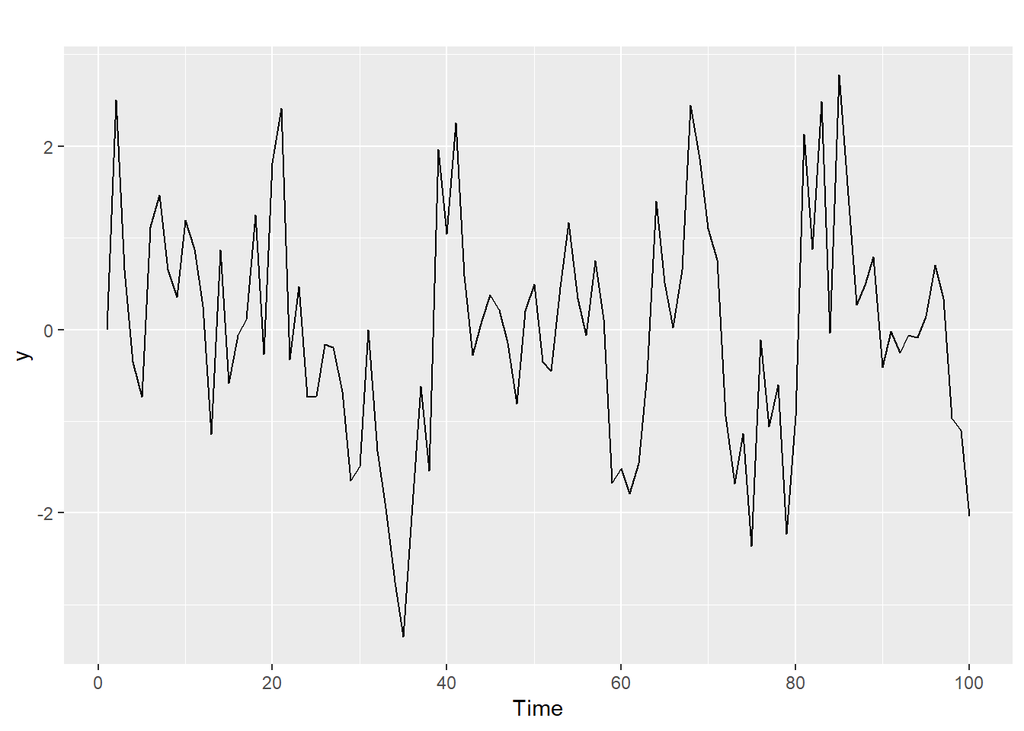

```r
# 0.6
autoplot(y)
```

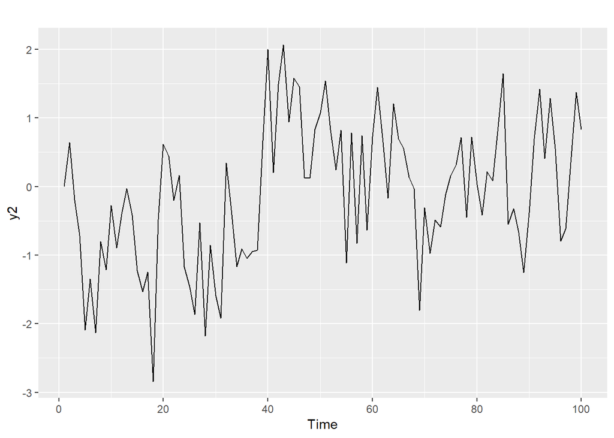

```r
# lower - 0.5
y2 <- ts(numeric(100))
e2 <- rnorm(100)
for(i in 2:100)
  y2[i] <- 0.5*y2[i-1] + e2[i]

autoplot(y2)
```

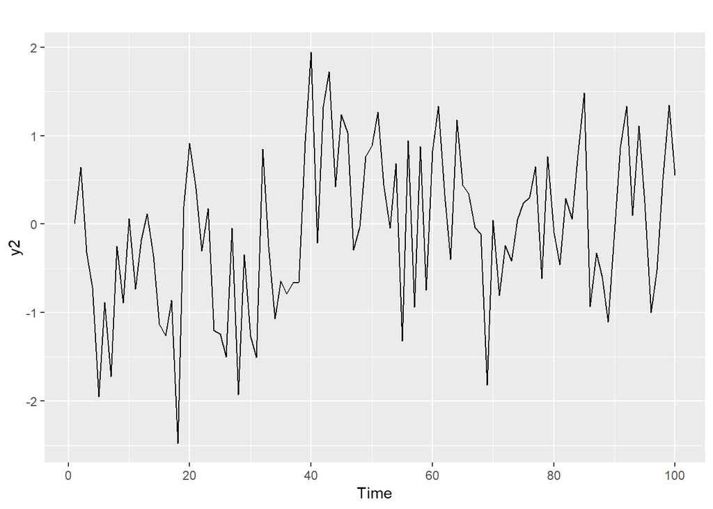

```r
# 0.3
for(i in 2:100)
  y2[i] <- 0.3*y2[i-1] + e2[i]

autoplot(y2)
```

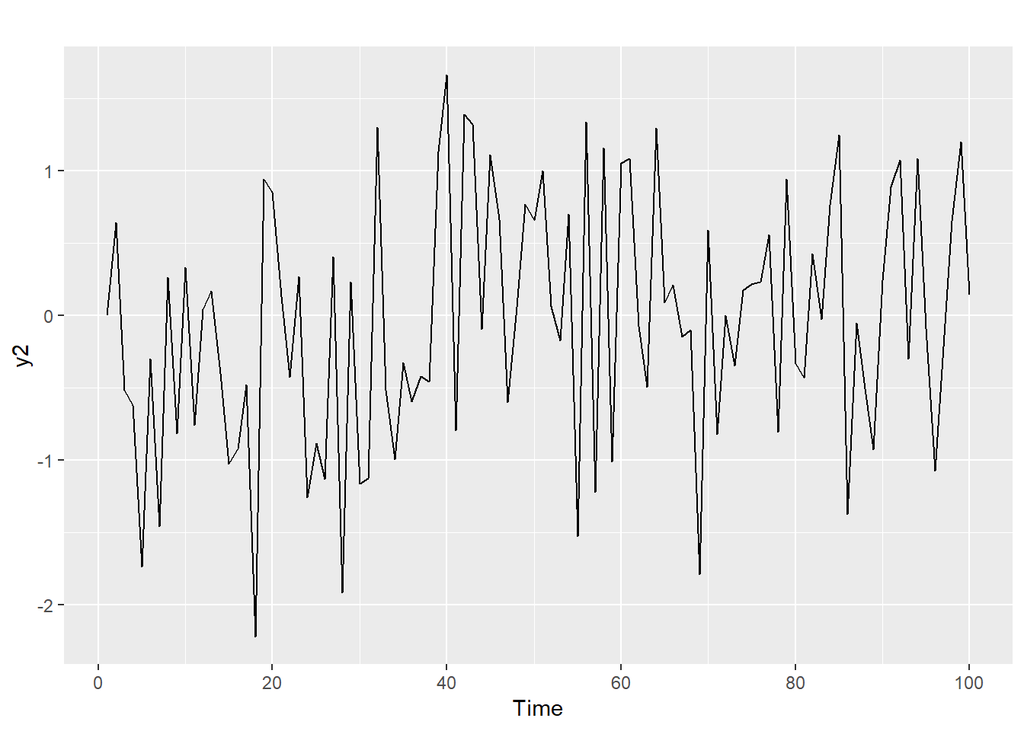

```r
# 0
for(i in 2:100)
  y2[i] <- 0*y2[i-1] + e2[i]

# param = 0 graphs
autoplot(y2)
```

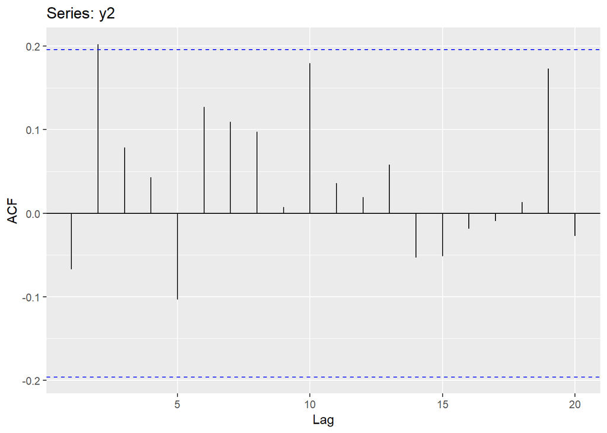

```r
ggAcf(y2)
```

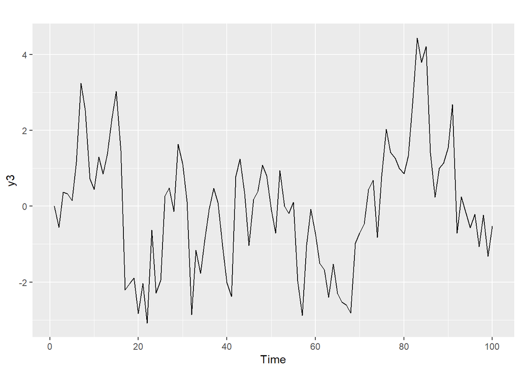

```r
# higher - 0.7
y3 <- ts(numeric(100))
e3 <- rnorm(100)
for(i in 2:100)
  y3[i] <- 0.7*y3[i-1] + e3[i]

autoplot(y3)
```